# Lab1_Ekaterina_Dragunskaia_Q3_Q4

Ekaterina Dragunskaia

## Q3

```r
#loading the `eco_data`:
eco_data <- read.csv(url("https://raw.githubusercontent.com/DataScienceHU/DataAnalysisR_2020/master/data/economic_data.csv"))
```

### a

1. Rename columns using basic R
2. Now we will check if we succed to rename the columns using the function names.

```r
#1
new_names <- c("country", "S_country", "feature", "feature_code", "Y2018V", "Y2019V")
for (i in 1:length(names(eco_data))){
  names(eco_data)[i] <- new_names[i]
}
#2
names(eco_data)
```

```
## [1] "country"      "S_country"    "feature"      "feature_code" "Y2018V"
## [6] "Y2019V"
```

### b

1. First we will found all new names of our new data frame.
2. Now we have to find all countries. For that we will use function unique. But there is an rows at the end wich are not contries and we have to delete them so we will use function tail to find how much of them we have to delete, and that delete them using slicing.
3. Now we are creating new data.frame.
4. Now we are entering our data to the data frame
5. Printing head of the data

```r
#1
features_name <- as.vector(unique(eco_data$feature))
col_names_eco <- c("country")
col_names_eco[2:11] <- features_name[1:10]
#2
countries_eco <- unique(eco_data$country)
tail(countries_eco)
```

```
## [1] Sub-Saharan Africa (IDA & IBRD countries)
## [2] Upper middle income
## [3] World
## [4]
## [5] Data from database: World Development Indicators
## [6] Last Updated: 03/18/2020
## 267 Levels:  Afghanistan Albania Algeria American Samoa Andorra ... Zimbabwe
```

```r
countries_eco <- countries_eco[1:(length(countries_eco)-3)]
tail(countries_eco)
```

```
## [1] South Asia (IDA & IBRD)
## [2] Sub-Saharan Africa
## [3] Sub-Saharan Africa (excluding high income)
## [4] Sub-Saharan Africa (IDA & IBRD countries)
## [5] Upper middle income
## [6] World
## 267 Levels:  Afghanistan Albania Algeria American Samoa Andorra ... Zimbabwe
```

```r
#3
eco <- as.data.frame(matrix(nrow = length(countries_eco), ncol = length(col_names_eco)))
colnames(eco) <- col_names_eco
#4
eco$country <- countries_eco
for (i in 1:10){
  eco[,(i+1)] <- eco_data$Y2018V[which(eco_data$feature == features_name[i])]
}
#5
head(eco)
```

```
##          country GDP (current US$) GDP (constant LCU)
## 1    Afghanistan  19362969582.3643   511432475534.156
## 2        Albania   15102500898.238      1513259270000
## 3        Algeria   173757952824.25   6123376375970.86
## 4 American Samoa         636000000          608000000
## 5        Andorra  3236543909.34844         2002840000
## 6         Angola   105750987618.63      1552771000000
##   GDP, PPP (current international $)
## 1                   72672245387.0863
## 2                   38306694289.2319
## 3                   653771569286.319
## 4                                 ..
## 5                                 ..
## 6                   198795526982.065
##   Unemployment, female (% of female labor force) (modeled ILO estimate)
```

[output cut: 41 more lines]

### c

Rename using basic R

```r
names(eco)
```

```
##  [1] "country"
##  [2] "GDP (current US$)"
##  [3] "GDP (constant LCU)"
##  [4] "GDP, PPP (current international $)"
##  [5] "Unemployment, female (% of female labor force) (modeled ILO estimate)"
##  [6] "Unemployment, male (% of male labor force) (modeled ILO estimate)"
##  [7] "Unemployment, total (% of total labor force) (modeled ILO estimate)"
##  [8] "Population, total"
##  [9] "Population in the largest city (% of urban population)"
## [10] "Government expenditure on education, total (% of GDP)"
## [11] "Population ages 65 and above (% of total population)"
```

```r
names(eco)[2] <- "GDP"
names(eco)[11] <- "pop65"
names(eco)[9] <- "pop_city_ratio"
names(eco)[8] <- "pop_total"
names(eco)
```

```
##  [1] "country"
##  [2] "GDP"
##  [3] "GDP (constant LCU)"
##  [4] "GDP, PPP (current international $)"
##  [5] "Unemployment, female (% of female labor force) (modeled ILO estimate)"
##  [6] "Unemployment, male (% of male labor force) (modeled ILO estimate)"
##  [7] "Unemployment, total (% of total labor force) (modeled ILO estimate)"
##  [8] "pop_total"
##  [9] "pop_city_ratio"
## [10] "Government expenditure on education, total (% of GDP)"
## [11] "pop65"
```

### d

```r
library(tidyverse)
library(dplyr)
library(data.table)
#1
eco_gdp = eco %>% arrange(desc(GDP)) %>% head(eco_gdp, n = 10)
eco_gdp
```

```
##               country              GDP GDP (constant LCU)
## 1           IDA blend 993777987034.123                 ..
## 2               Haiti 9658721168.86849        16277000900
## 3              Rwanda  9508715596.4368      7268683000000
## 4               Niger  9290938457.2883    3672172547085.1
## 5             Vanuatu  914301119.28749    68623014954.217
## 6         Netherlands 913658465709.125       744505272100
## 7           Sri Lanka 88900770857.6351      9644727117600
## 8               Kenya 87908262519.9164      4794832560800
## 9               World 85909727209568.5                 ..
## 10 Dominican Republic 85555390387.0355   2500289853665.52
##    GDP, PPP (current international $)
## 1                    3120570128797.48
## 2                    20762715967.6003
## 3                    27698509345.5708
```

[output cut: 62 more lines]

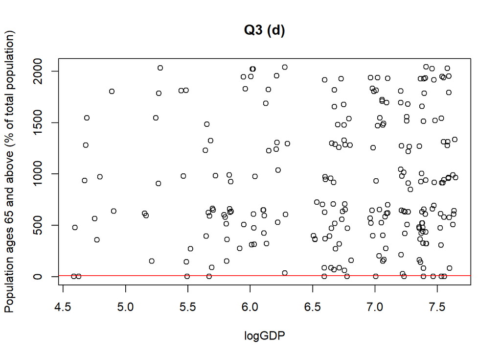

```r
#2
eco_pop65 = eco %>% arrange(desc(GDP)) %>% head(eco_pop65, n = round(length(eco$country)*0.9)) %>% mutate(logGDP = log(as.double(GDP)))

#3
plot(x = eco_pop65$logGDP, y = eco_pop65$pop65,
     main = "Q3 (d)",
     xlab = "logGDP",
     ylab = "Population ages 65 and above (% of total population)",
     )
abline(lm(eco_pop65$logGDP~eco_pop65$pop65), col = "red")
```

## Q2 This code is here temperary to make work easily.

```r
data_con = read.csv(url("https://data.humdata.org/hxlproxy/data/download/time_series_covid19_confirmed_global_narrow.csv?dest=data_edit&filter01=merge&merge-url01=https%3A%2F%2Fdocs.google.com%2Fspreadsheets%2Fd%2Fe%2F2PACX-1vTglKQRXpkKSErDiWG6ycqEth32MY0reMuVGhaslImLjfuLU0EUgyyu2e-3vKDArjqGX7dXEBV8FJ4f%2Fpub%3Fgid%3D1326629740%26single%3Dtrue%26output%3Dcsv&merge-keys01=%23country%2Bname&merge-tags01=%23country%2Bcode%2C%23region%2Bmain%2Bcode%2C%23region%2Bsub%2Bcode%2C%23region%2Bintermediate%2Bcode&filter02=merge&merge-url02=https%3A%2F%2Fdocs.google.com%2Fspreadsheets%2Fd%2Fe%2F2PACX-1vTglKQRXpkKSErDiWG6ycqEth32MY0reMuVGhaslImLjfuLU0EUgyyu2e-3vKDArjqGX7dXEBV8FJ4f%2Fpub%3Fgid%3D398158223%26single%3Dtrue%26output%3Dcsv&merge-keys02=%23adm1%2Bname&merge-tags02=%23country%2Bcode%2C%23region%2Bmain%2Bcode%2C%23region%2Bsub%2Bcode%2C%23region%2Bintermediate%2Bcode&merge-replace02=on&merge-overwrite02=on&filter03=explode&explode-header-att03=date&explode-value-att03=value&filter04=rename&rename-oldtag04=%23affected%2Bdate&rename-newtag04=%23date&rename-header04=Date&filter05=rename&rename-oldtag05=%23affected%2Bvalue&rename-newtag05=%23affected%2Binfected%2Bvalue%2Bnum&rename-header05=Value&filter06=clean&clean-date-tags06=%23date&filter07=sort&sort-tags07=%23date&sort-reverse07=on&filter08=sort&sort-tags08=%23country%2Bname%2C%23adm1%2Bname&tagger-match-all=on&tagger-default-tag=%23affected%2Blabel&tagger-01-header=province%2Fstate&tagger-01-tag=%23adm1%2Bname&tagger-02-header=country%2Fregion&tagger-02-tag=%23country%2Bname&tagger-03-header=lat&tagger-03-tag=%23geo%2Blat&tagger-04-header=long&tagger-04-tag=%23geo%2Blon&header-row=1&url=https%3A%2F%2Fraw.githubusercontent.com%2FCSSEGISandData%2FCOVID-19%2Fmaster%2Fcsse_covid_19_data%2Fcsse_covid_19_time_series%2Ftime_series_covid19_confirmed_global.csv"), comment.char = "#")

data_death = read.csv(url("https://data.humdata.org/hxlproxy/data/download/time_series_covid19_deaths_global_narrow.csv?dest=data_edit&filter01=merge&merge-url01=https%3A%2F%2Fdocs.google.com%2Fspreadsheets%2Fd%2Fe%2F2PACX-1vTglKQRXpkKSErDiWG6ycqEth32MY0reMuVGhaslImLjfuLU0EUgyyu2e-3vKDArjqGX7dXEBV8FJ4f%2Fpub%3Fgid%3D1326629740%26single%3Dtrue%26output%3Dcsv&merge-keys01=%23country%2Bname&merge-tags01=%23country%2Bcode%2C%23region%2Bmain%2Bcode%2C%23region%2Bsub%2Bcode%2C%23region%2Bintermediate%2Bcode&filter02=merge&merge-url02=https%3A%2F%2Fdocs.google.com%2Fspreadsheets%2Fd%2Fe%2F2PACX-1vTglKQRXpkKSErDiWG6ycqEth32MY0reMuVGhaslImLjfuLU0EUgyyu2e-3vKDArjqGX7dXEBV8FJ4f%2Fpub%3Fgid%3D398158223%26single%3Dtrue%26output%3Dcsv&merge-keys02=%23adm1%2Bname&merge-tags02=%23country%2Bcode%2C%23region%2Bmain%2Bcode%2C%23region%2Bsub%2Bcode%2C%23region%2Bintermediate%2Bcode&merge-replace02=on&merge-overwrite02=on&filter03=explode&explode-header-att03=date&explode-value-att03=value&filter04=rename&rename-oldtag04=%23affected%2Bdate&rename-newtag04=%23date&rename-header04=Date&filter05=rename&rename-oldtag05=%23affected%2Bvalue&rename-newtag05=%23affected%2Binfected%2Bvalue%2Bnum&rename-header05=Value&filter06=clean&clean-date-tags06=%23date&filter07=sort&sort-tags07=%23date&sort-reverse07=on&filter08=sort&sort-tags08=%23country%2Bname%2C%23adm1%2Bname&tagger-match-all=on&tagger-default-tag=%23affected%2Blabel&tagger-01-header=province%2Fstate&tagger-01-tag=%23adm1%2Bname&tagger-02-header=country%2Fregion&tagger-02-tag=%23country%2Bname&tagger-03-header=lat&tagger-03-tag=%23geo%2Blat&tagger-04-header=long&tagger-04-tag=%23geo%2Blon&header-row=1&url=https%3A%2F%2Fraw.githubusercontent.com%2FCSSEGISandData%2FCOVID-19%2Fmaster%2Fcsse_covid_19_data%2Fcsse_covid_19_time_series%2Ftime_series_covid19_deaths_global.csv"), comment.char = "#")

data_rec = read.csv (url("https://data.humdata.org/hxlproxy/data/download/time_series_covid19_recovered_global_narrow.csv?dest=data_edit&filter01=merge&merge-url01=https%3A%2F%2Fdocs.google.com%2Fspreadsheets%2Fd%2Fe%2F2PACX-1vTglKQRXpkKSErDiWG6ycqEth32MY0reMuVGhaslImLjfuLU0EUgyyu2e-3vKDArjqGX7dXEBV8FJ4f%2Fpub%3Fgid%3D1326629740%26single%3Dtrue%26output%3Dcsv&merge-keys01=%23country%2Bname&merge-tags01=%23country%2Bcode%2C%23region%2Bmain%2Bcode%2C%23region%2Bsub%2Bcode%2C%23region%2Bintermediate%2Bcode&filter02=merge&merge-url02=https%3A%2F%2Fdocs.google.com%2Fspreadsheets%2Fd%2Fe%2F2PACX-1vTglKQRXpkKSErDiWG6ycqEth32MY0reMuVGhaslImLjfuLU0EUgyyu2e-3vKDArjqGX7dXEBV8FJ4f%2Fpub%3Fgid%3D398158223%26single%3Dtrue%26output%3Dcsv&merge-keys02=%23adm1%2Bname&merge-tags02=%23country%2Bcode%2C%23region%2Bmain%2Bcode%2C%23region%2Bsub%2Bcode%2C%23region%2Bintermediate%2Bcode&merge-replace02=on&merge-overwrite02=on&filter03=explode&explode-header-att03=date&explode-value-att03=value&filter04=rename&rename-oldtag04=%23affected%2Bdate&rename-newtag04=%23date&rename-header04=Date&filter05=rename&rename-oldtag05=%23affected%2Bvalue&rename-newtag05=%23affected%2Binfected%2Bvalue%2Bnum&rename-header05=Value&filter06=clean&clean-date-tags06=%23date&filter07=sort&sort-tags07=%23date&sort-reverse07=on&filter08=sort&sort-tags08=%23country%2Bname%2C%23adm1%2Bname&tagger-match-all=on&tagger-default-tag=%23affected%2Blabel&tagger-01-header=province%2Fstate&tagger-01-tag=%23adm1%2Bname&tagger-02-header=country%2Fregion&tagger-02-tag=%23country%2Bname&tagger-03-header=lat&tagger-03-tag=%23geo%2Blat&tagger-04-header=long&tagger-04-tag=%23geo%2Blon&header-row=1&url=https%3A%2F%2Fraw.githubusercontent.com%2FCSSEGISandData%2FCOVID-19%2Fmaster%2Fcsse_covid_19_data%2Fcsse_covid_19_time_series%2Ftime_series_covid19_recovered_global.csv"), comment.char = "#")

#Change to Date type#
for (i in list(data_con, data_death, data_rec)) {
     i$Date = as.Date(i$Date)}

#Aggregated data-frames using 'aggregate' function#
datasets= list(cases.agg= data_con, death.agg = data_death, recover.agg= data_rec)
agg= lapply(datasets, function(x) {aggregate(Value ~ Country.Region + Date, data = x, FUN= sum) })
cases.agg <- agg[[1]]
death.agg <- agg[[2]]
recovered.agg <- agg[[3]]
```

### a

??? Makes new names for columns (I tried to use by instead but it doesnt work

```r
names(cases.agg)[3] <- "cases"
names(recovered.agg)[3] <- "recovered"
names(death.agg)[3] <- "death"
corona <- cases.agg %>% left_join(death.agg) %>% left_join(recovered.agg)
#corona = cases.agg %>% left_join(death.agg, by = c("Country.Region" = "Country.Region")) %>% left_join(recovered.agg, by = c("Country.Region" = "Country.Region"))
```

### b

Column `Country.Region`/`country` joining factors with different levels, coercing to character vector  
What does that mean? And alsi I didnwt understand which exatly data we don’t need.

```r
corona_eco = corona %>% inner_join(eco, by = c("Country.Region" = "country"))
```